# R Bootcamp 1.4 Data frames in R

last update: 2021-08-04

## R Space

> Data should be tidy with *mis en place*

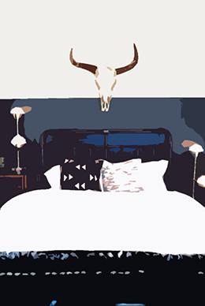

## What you will learn

- “Tidy Data” concept
- Common data file types
- Excel, data setup, and the Data Dictionary
- Getting data into R
- Manipulating variables
- Practice exercises

## “Tidy Data” concept

[figure not shown]

## “Tidy Data” concept

The data should be in a standard, accessible, reproducible, non-haphazard, format

- One column per variable
- One row per observational unit
- Thought given to sympathetic data “codification”
- explanation of variables
- Variable naming conventions

## Common data file types

**Delimited text files**

- .csv, .txt, tab-delimited, others
- first row with variable names
- problem with explanation of variables

**Excel is okay**, but must be **Tidy**

**Avoid proprietary formats** (like SPSS, Genstat, etc.)

## Data formats

[figure not shown]

Untidy data in Excel

## Data formats

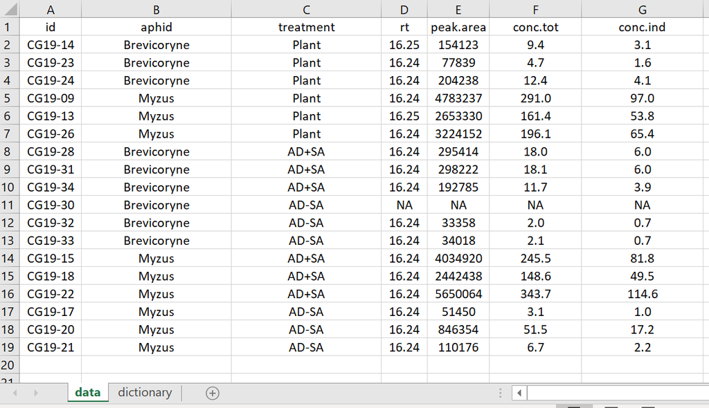

Tidy data in Excel

## Data formats

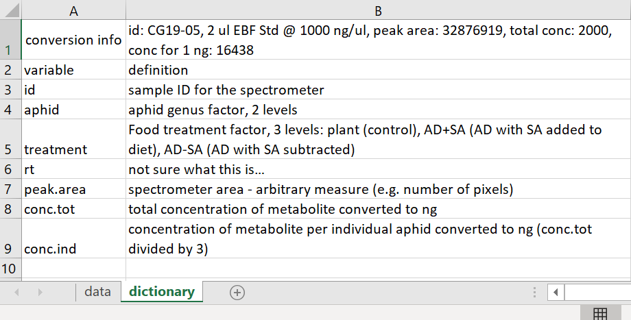

Data dictionary

## Data formats

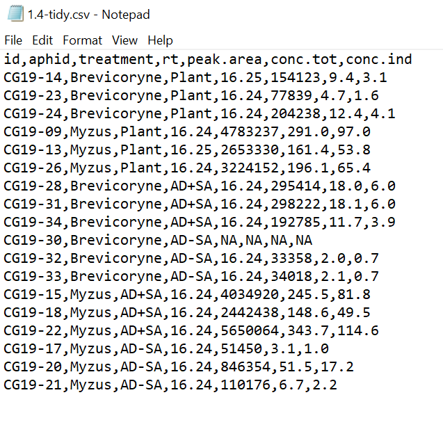

Tidy csv

## Getting data into R

Step 1 Set your working directory with code, or RStudio menus

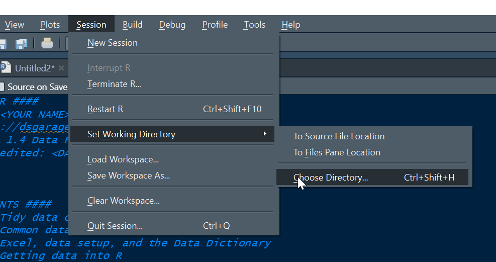

Working directory menus

## Getting data into R

Different data file types require different functions

for .csv `read.csv()`

for other delimited `read.table()`

for Excel `library(openxlsx); read.xlsx()`

many others exist

## Manipulating variables

- `names()` function
- The use of the `$` operator for data frames
- The use of the `str()` function for data frames
- The use of the index operator `[ , ]`
- The use of the `attach()` function

## Live coding

[figure not shown]